# Codebook for statespending

Autogenerated data summary from dataReporter

2022-02-28 20:30:26

# Data report overview

The dataset examined has the following dimensions:

| Feature | Result |
| --- | --- |
| Number of observations | 816 |
| Number of variables | 9 |

# Codebook summary table

| Label | Variable | Class | # unique values | Missing | Description |
| --- | --- | --- | --- | --- | --- |
|  | **year** | character | 16 | 0.00 % |  |
|  | **state** | character | 51 | 0.00 % |  |
|  | **education** | numeric | 816 | 0.00 % |  |
|  | **higher_education** | numeric | 816 | 0.00 % |  |
|  | **welfare** | numeric | 816 | 0.00 % |  |
|  | **hospitals** | numeric | 816 | 0.00 % |  |
|  | **highways** | numeric | 816 | 0.00 % |  |
|  | **police** | numeric | 816 | 0.00 % |  |
|  | **other** | numeric | 816 | 0.00 % |  |

# Variable list

## year

| Feature | Result |
| --- | --- |
| Variable type | character |
| Number of missing obs. | 0 (0 %) |
| Number of unique values | 16 |
| Mode | “2004” |

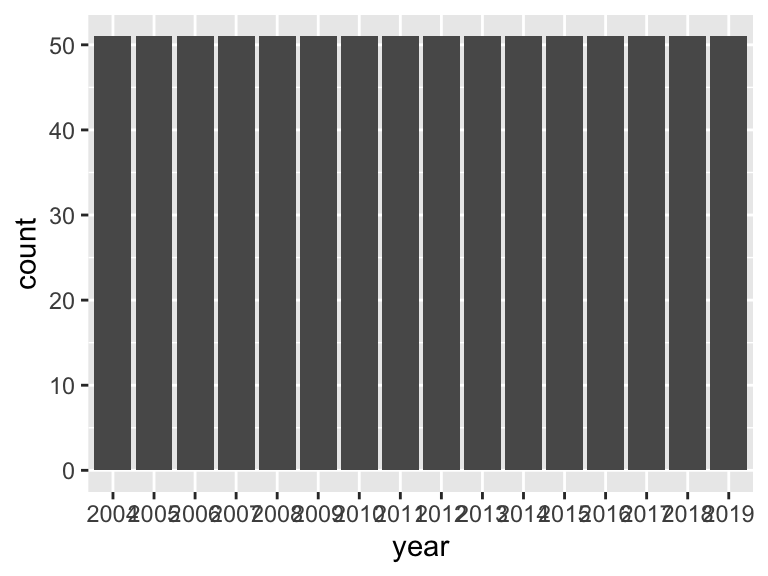

- Observed factor levels: "2004", "2005", "2006", "2007", "2008", "2009", "2010", "2011", "2012", "2013", "2014", "2015", "2016", "2017", "2018", "2019".

## state

| Feature | Result |
| --- | --- |
| Variable type | character |
| Number of missing obs. | 0 (0 %) |
| Number of unique values | 51 |
| Mode | “Alabama” |

[figure not shown]

- Observed factor levels: "Alabama", "Alaska", "Arizona", "Arkansas", "California", "Colorado", "Connecticut", "Delaware", "District of Columbia", "Florida", "Georgia", "Hawaii", "Idaho", "Illinois", "Indiana", "Iowa", "Kansas", "Kentucky", "Louisiana", "Maine", "Maryland", "Massachusetts", "Michigan", "Minnesota", "Mississippi", "Missouri", "Montana", "Nebraska", "Nevada", "New Hampshire", "New Jersey", "New Mexico", "New York", "North Carolina", "North Dakota", "Ohio", "Oklahoma", "Oregon", "Pennsylvania", "Rhode Island", "South Carolina", "South Dakota", "Tennessee", "Texas", "Utah", "Vermont", "Virginia", "Washington", "West Virginia", "Wisconsin", "Wyoming".

## education

| Feature | Result |
| --- | --- |
| Variable type | numeric |
| Number of missing obs. | 0 (0 %) |
| Number of unique values | 816 |
| Median | 1726.41 |
| 1st and 3rd quartiles | 1528.69; 2036.3 |
| Min. and max. | 1100.04; 4187.74 |

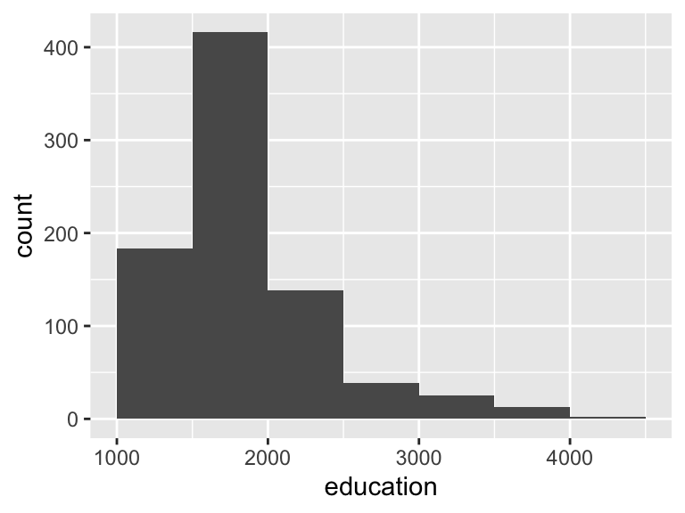

## higher_education

| Feature | Result |
| --- | --- |
| Variable type | numeric |
| Number of missing obs. | 0 (0 %) |
| Number of unique values | 816 |
| Median | 820.92 |
| 1st and 3rd quartiles | 644.5; 989.22 |
| Min. and max. | 178.75; 1613.63 |

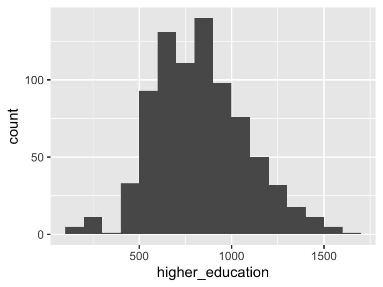

## welfare

| Feature | Result |
| --- | --- |
| Variable type | numeric |
| Number of missing obs. | 0 (0 %) |
| Number of unique values | 816 |
| Median | 1478.11 |
| 1st and 3rd quartiles | 1205.36; 1948.8 |
| Min. and max. | 619.91; 5779.37 |

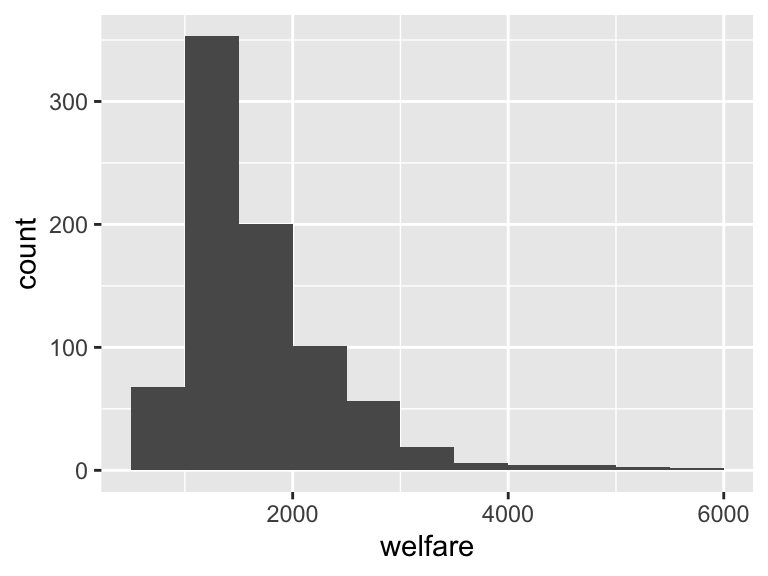

## hospitals

| Feature | Result |
| --- | --- |
| Variable type | numeric |
| Number of missing obs. | 0 (0 %) |
| Number of unique values | 816 |
| Median | 633.35 |
| 1st and 3rd quartiles | 458.03; 866.67 |
| Min. and max. | 117.02; 3171.15 |

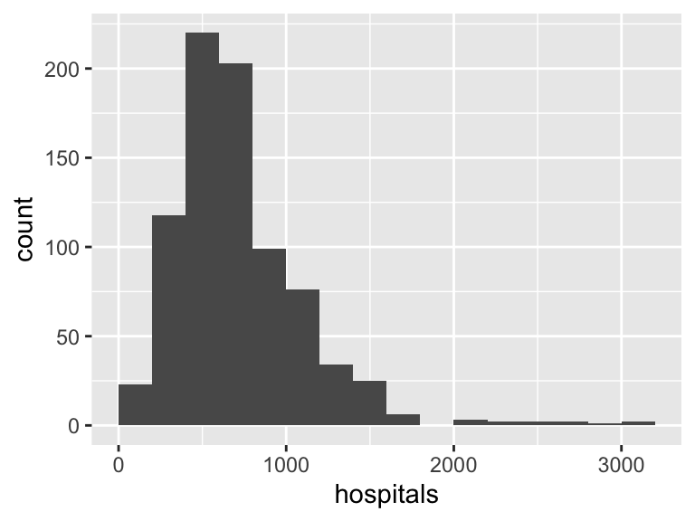

## highways

| Feature | Result |
| --- | --- |
| Variable type | numeric |
| Number of missing obs. | 0 (0 %) |
| Number of unique values | 816 |
| Median | 537.85 |
| 1st and 3rd quartiles | 431.96; 659.15 |
| Min. and max. | 125.53; 2441.34 |

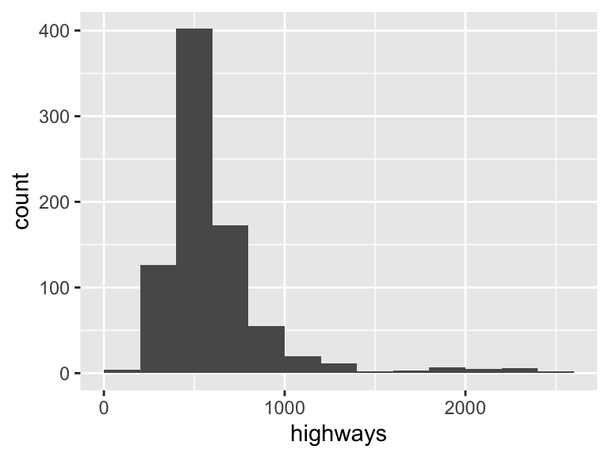

## police

| Feature | Result |
| --- | --- |
| Variable type | numeric |
| Number of missing obs. | 0 (0 %) |
| Number of unique values | 816 |
| Median | 270.94 |
| 1st and 3rd quartiles | 227.41; 329.98 |
| Min. and max. | 119.82; 1018.35 |

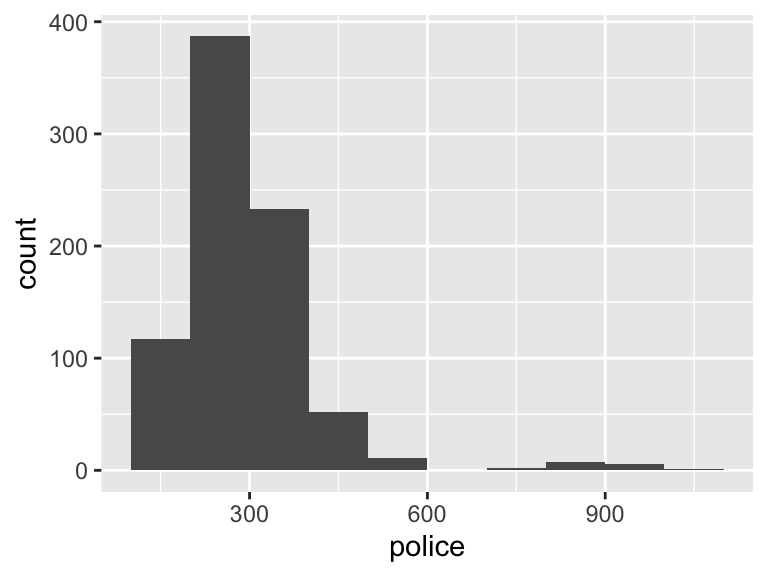

## other

| Feature | Result |
| --- | --- |
| Variable type | numeric |
| Number of missing obs. | 0 (0 %) |
| Number of unique values | 816 |
| Median | 2287.94 |
| 1st and 3rd quartiles | 1945.36; 2840.9 |
| Min. and max. | 1305.9; 8880.33 |

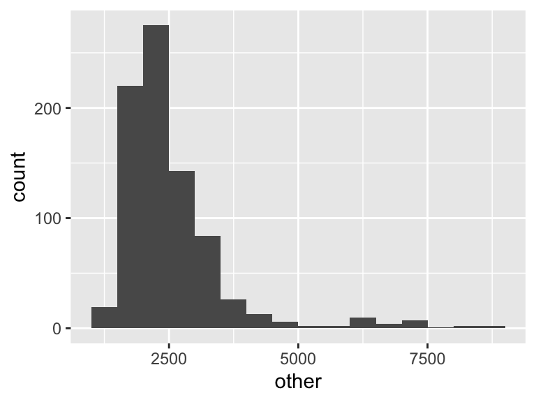

Report generation information:

- Created by: Natalie Meltzer (username: `nataliemeltzer`).
- Report creation time: Mon Feb 28 2022 20:30:27
- Report was run from directory: `/Users/nataliemeltzer/Library/CloudStorage/Box-Box/glhlth562/glhlth562final/proposal`
- dataReporter v1.0.2 [Pkg: 2021-11-11 from CRAN (R 4.1.0)]
- R version 4.1.2 (2021-11-01).
- Platform: x86_64-apple-darwin17.0 (64-bit)(macOS Big Sur 10.16).
- Function call: `dataReporter::makeDataReport(data = statespending, mode = c("summarize", "visualize", "check"), smartNum = FALSE, file = "codebook_statespending.Rmd", vol = "", checks = list(character = "showAllFactorLevels", factor = "showAllFactorLevels", labelled = "showAllFactorLevels", haven_labelled = "showAllFactorLevels", numeric = NULL, integer = NULL, logical = NULL, Date = NULL), listChecks = FALSE, maxProbVals = Inf, codebook = TRUE, reportTitle = "Codebook for statespending")`